# Exercises in R

# Part 1

## Causal Diagrams in R

## Why Causal Diagrams?

- Associations don’t necessarily imply causation, we can be **explicit about our assumptions**
- A **Directed Acyclic Graph (DAG)** encodes causal structure visually
- DAGs help us identify **confounders** to adjust for, **colliders** to avoid conditioning on, and whether our causal question is even answerable

## Example

Does regular exercise **cause** lower systolic blood pressure?

**Exposure:** `exercise`: does the patient exercise regularly? (yes/no)

**Outcome:** `systolic_bp`: systolic blood pressure (mmHg)

**Proposed confounders:**

| Variable | Column |
| --- | --- |
| Age | `age` |
| BMI | `bmi` |
| Diet quality | `diet_quality` |
| Smoking status | `smoking` |

## Setup

```r
library(tidyverse)
library(ggdag)
library(dagitty)

set.seed(1)
```

## Specify a DAG with `dagify()`

```r
bp_dag <- dagify(
  systolic_bp ~ exercise + age + bmi + diet_quality + smoking,
  exercise    ~ age + bmi + diet_quality + smoking,
  smoking     ~ diet_quality,
  exposure = "exercise",
  outcome  = "systolic_bp",
  labels = c(
    exercise    = "Regular\nExercise",
    systolic_bp = "Systolic BP",
    age         = "Age",
    bmi         = "BMI",
    diet_quality = "Diet\nQuality",
    smoking     = "Smoking"
  )
)
```

**Note**

Each formula reads as “this thing is **caused by** these things”

## Plot with `ggdag()`

```r
ggdag(bp_dag, use_labels = "label", text = FALSE) +
  theme_dag()
```

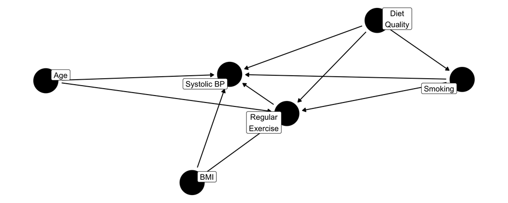

## Time-Ordered Layout

```r
bp_dag_to <- dagify(
  systolic_bp ~ exercise + age + bmi + diet_quality + smoking,
  exercise    ~ age + bmi + diet_quality + smoking,
  smoking     ~ diet_quality,
  exposure = "exercise",
  outcome  = "systolic_bp",
  coords   = time_ordered_coords(),        # <-- new!
  labels = c(
    exercise = "Regular\nExercise",
    systolic_bp = "Systolic BP",
    age = "Age", bmi = "BMI",
    diet_quality = "Diet\nQuality",
    smoking = "Smoking"
  )
)
ggdag(bp_dag_to, use_labels = "label", text = FALSE) + theme_dag()
```

## Time-Ordered Layout

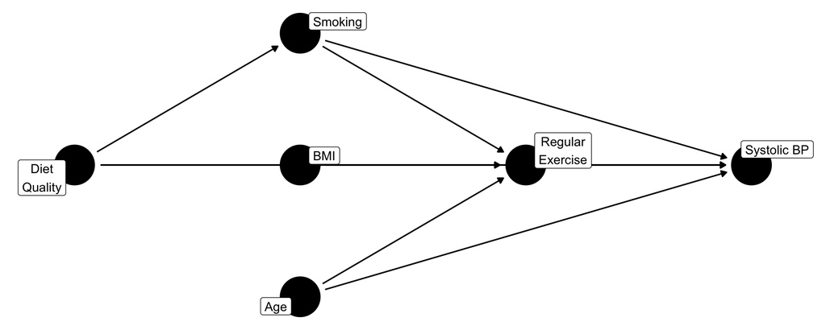

## Open Paths with `ggdag_paths()`

```r
ggdag_paths(
  bp_dag,
  use_labels = "label",
  text = FALSE
) +
  theme_dag()
```

## Open Paths with `ggdag_paths()`

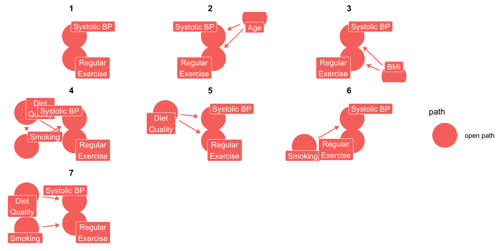

## Adjustment Sets

What do we need to control for to close all backdoor paths?

```r
ggdag_adjustment_set(
  bp_dag,
  use_labels = "label",
  text = FALSE
) +
  theme_dag()
```

## Adjustment Sets

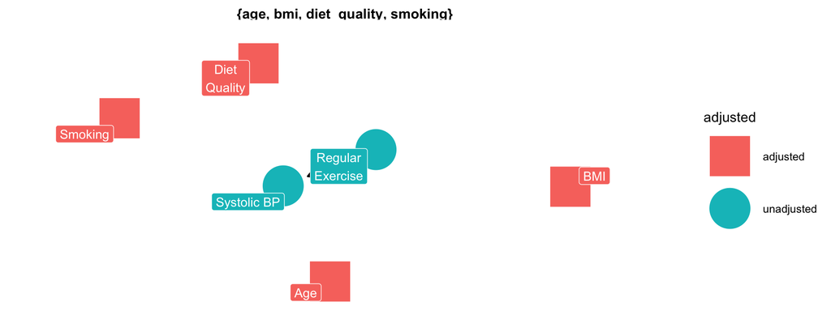

## Adjustment Sets in Text

```r
dagitty::adjustmentSets(bp_dag)
```

```
{ age, bmi, diet_quality, smoking }
```

**Note**

If there is more than one adjustment set, you can adjust for **any one** of these sets and you’ve blocked all backdoor paths.

## What if a Variable is Unmeasured?

```r
bp_dag_latent <- dagify(
  systolic_bp ~ exercise + age + bmi + diet_quality + smoking,
  exercise    ~ age + bmi + diet_quality + smoking,
  smoking     ~ diet_quality,
  exposure = "exercise", outcome = "systolic_bp",
  latent   = "diet_quality",          # <-- unmeasured!
  labels = c(exercise = "Regular\nExercise", systolic_bp = "Systolic BP",
             age = "Age", bmi = "BMI",
             diet_quality = "Diet\nQuality", smoking = "Smoking")
)
ggdag_adjustment_set(bp_dag_latent, use_labels = "label", text = FALSE) +
  theme_dag()
```

## What if a Variable is Unmeasured?

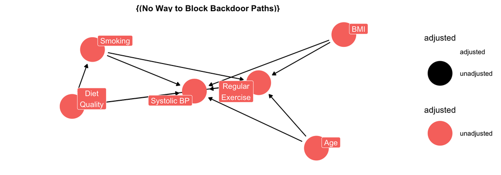

## Part 1 Takeaways

- Use `dagify()` to write down your causal assumptions
- `ggdag()` and `ggdag_paths()` reveal open (confounding) paths
- `ggdag_adjustment_set()` tells you what to control for
- `time_ordered_coords()` makes DAGs cleaner and more readable

# Part 2

## Propensity Scores

## What is a Propensity Score?

The **propensity score** is the probability of receiving the exposure given observed covariates:

$$e(X) = P(\text{Exercise} = 1 \mid X)$$

- Collapses all confounders into a **single number**
- Patients with the same propensity score are (in expectation) balanced on all observed confounders
- We estimate it with **logistic regression**

## Fit a Propensity Score Model

```r
library(broom)

propensity_model <- glm(
  exercise ~ age + bmi + diet_quality + smoking,
  data   = health_study,
  family = binomial()
)

tidy(propensity_model)
```

```
# A tibble: 6 × 5
  term             estimate std.error statistic p.value
  <chr>               <dbl>     <dbl>     <dbl>   <dbl>
1 (Intercept)      -0.139      0.851    -0.163  0.870
2 age               0.00878    0.0104    0.846  0.398
3 bmi              -0.0712     0.0258   -2.76   0.00580
4 diet_qualitygood  0.530      0.259     2.05   0.0404
5 diet_qualitypoor  0.00984    0.300     0.0328 0.974
6 smoking          -0.969      0.322    -3.01   0.00258
```

## Add Propensity Scores with `augment()`

```r
health_ps <- propensity_model |>
  augment(type.predict = "response", data = health_study)

health_ps |>
  select(id, exercise, .fitted) |>
  head(6)
```

```
# A tibble: 6 × 3
     id exercise .fitted
  <int>    <int>   <dbl>
1     1        0   0.163
2     2        0   0.108
3     3        0   0.130
4     4        0   0.158
5     5        0   0.168
6     6        0   0.136
```

**Note**

`.fitted` is each person’s **estimated probability** of exercising

## Visualise the Propensity Score Distribution

```r
ggplot(health_ps,
       aes(x = .fitted, fill = factor(exercise))) +
  geom_histogram(bins = 30, alpha = 0.7, position = "identity") +
  scale_fill_manual(values = c("#E69F00", "#56B4E9"),
                    labels = c("No exercise", "Exercises")) +
  labs(x = "Propensity Score", fill = NULL) +
  theme_minimal()
```

## Visualise the Propensity Score Distribution

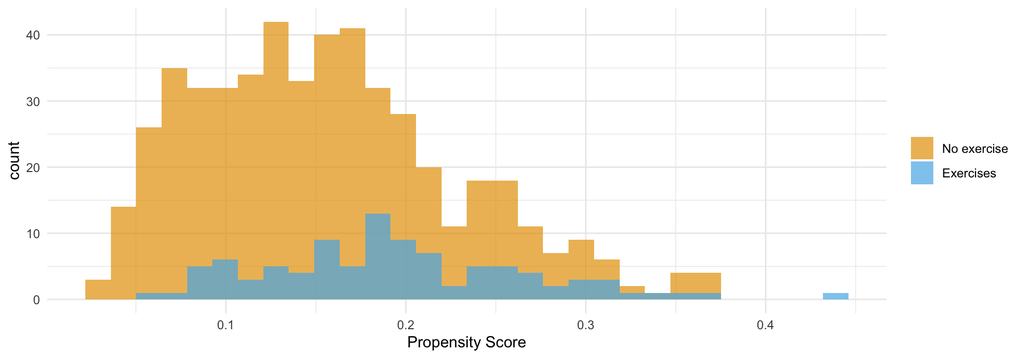

## Matching with `MatchIt`

```r
library(MatchIt)

matched_health <- matchit(
  exercise ~ age + bmi + diet_quality + smoking,
  data    = health_study,
  link    = "linear.logit",
  caliper = 0.2
)

matched_df <- get_matches(matched_health, id = "i")
nrow(matched_df)
```

```
[1] 192
```

## ATE Weights with `wt_ate()`

```r
library(propensity)

health_ps <- health_ps |>
  mutate(
    w_ate = wt_ate(.fitted, exercise),
    w_atm = wt_atm(.fitted, exercise)
  )

health_ps |> select(id, .fitted, exercise, w_ate, w_atm) |> head(4)
```

```
# A tibble: 4 × 5
     id .fitted exercise      w_ate      w_atm
  <int>   <dbl>    <int> <psw{ate}> <psw{atm}>
1     1   0.163        0   1.194443  0.1944430
2     2   0.108        0   1.121614  0.1216139
3     3   0.130        0   1.149312  0.1493122
4     4   0.158        0   1.187937  0.1879374
```

## Mirror Histogram: Before & After Weighting

```r
library(halfmoon)

ggplot(health_ps, aes(.fitted, fill = factor(exercise))) +
  geom_mirror_histogram(bins = 40, alpha = 0.5) +
  geom_mirror_histogram(aes(weight = w_ate), bins = 40, alpha = 0.5) +
  geom_hline(yintercept = 0, linewidth = 0.5) +
  scale_fill_manual(values = c("#E69F00", "#56B4E9"),
                    labels = c("No exercise", "Exercises")) +
  scale_y_continuous(labels = abs) +
  labs(x = "Propensity Score", fill = NULL) +
  theme_minimal()
```

## Mirror Histogram: Before & After Weighting

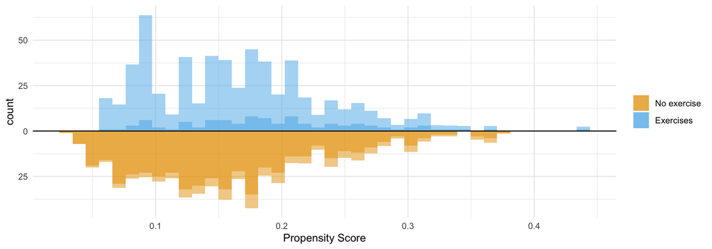

## Part 2 Takeaways

- Propensity scores are estimated with `glm(..., family = binomial())`
- `augment()` from **broom** appends fitted probabilities to your data
- `MatchIt::matchit()` + `get_matches()` creates a matched sample
- `wt_ate()` and `wt_atm()` from **propensity** compute IPW weights

# Part 3

## Propensity Score Diagnostics

## Why Diagnose?

- A propensity score model can be **technically correct but causally wrong**
- We need to check that the weighted/matched sample is **balanced**

## Key diagnostics:

- **Standardised Mean Differences (SMDs)** — Love plots
- **Empirical CDFs (ECDFs)** — distributional balance
- **Weighted tables** — publication-ready summaries

## Standardised Mean Differences

```r
smds <- health_ps |>
  mutate(age = as.numeric(age),
         bmi = as.numeric(bmi)) |>
  tidy_smd(
    .vars  = c(age, bmi, diet_quality, smoking),
    .group = exercise,
    .wts   = c(w_ate, w_atm)
  )

smds
```

## Standardised Mean Differences

```
# A tibble: 12 × 4
   variable     method   exercise      smd
   <chr>        <chr>    <chr>       <dbl>
 1 age          observed 1        -0.0497
 2 bmi          observed 1         0.287
 3 diet_quality observed 1         0.274
 4 smoking      observed 1         0.380
 5 age          w_ate    1        -0.0141
 6 bmi          w_ate    1         0.0291
 7 diet_quality w_ate    1         0.107
 8 smoking      w_ate    1         0.0477
 9 age          w_atm    1         0.0131
10 bmi          w_atm    1         0.00273
11 diet_quality w_atm    1         0.0199
12 smoking      w_atm    1        -0.00225
```

## Love Plot

```r
ggplot(smds,
       aes(x = abs(smd), y = variable,
           group = method, color = method)) +
  geom_love() +
  labs(x = "|SMD|", y = NULL, color = NULL) +
  theme_minimal()
```

**Note**

A rule-of-thumb threshold is |SMD| < 0.1 after weighting

## Love Plot

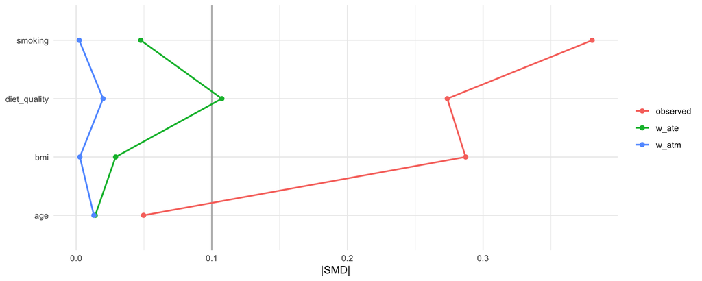

## ECDF: Unweighted

```r
ggplot(health_ps,
       aes(x = age, color = factor(exercise))) +
  geom_ecdf() +
  scale_color_manual("Exercise", values = c("#E69F00", "#56B4E9"),
                     labels = c("No", "Yes")) +
  labs(x = "Age", y = "Proportion ≤ x") +
  theme_minimal()
```

## ECDF: Unweighted

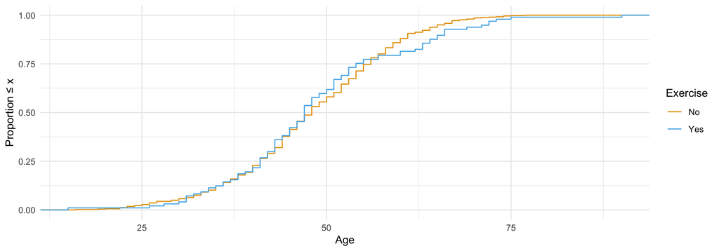

## ECDF: Weighted

```r
ggplot(health_ps,
       aes(x = age, color = factor(exercise))) +
  geom_ecdf(aes(weights = w_ate)) +
  scale_color_manual("Exercise", values = c("#E69F00", "#56B4E9"),
                     labels = c("No", "Yes")) +
  labs(x = "Age", y = "Proportion ≤ x (weighted)") +
  theme_minimal()
```

## ECDF: Weighted

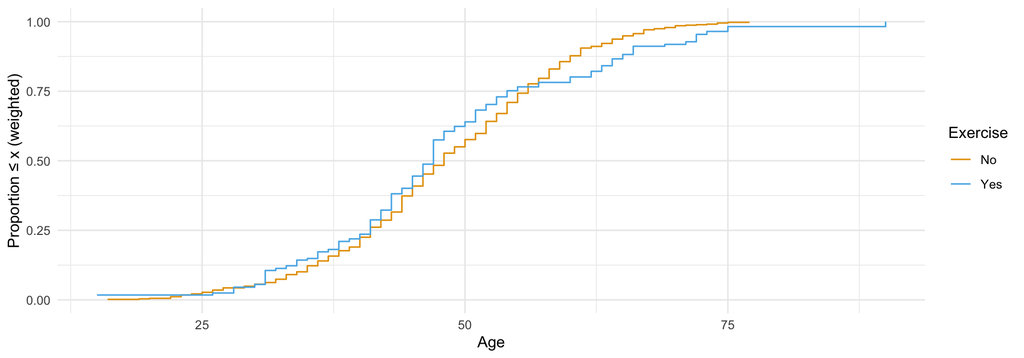

## Unweighted Table

```r
library(gtsummary)

health_ps |>
  select(exercise, age, bmi, diet_quality, smoking) |>
  tbl_summary(
    by = exercise,
  ) |>
  add_difference(everything() ~ "smd") |>
  modify_column_hide(conf.low)
```

## Unweighted Table

| **Characteristic** | **0** N = 503<sup>1</sup> | **1** N = 97<sup>1</sup> | **Difference**<sup>2</sup> |
| --- | --- | --- | --- |
| age | 48 (41, 56) | 47 (41, 54) | -0.05 |
| bmi | 27.5 (24.3, 30.5) | 26.1 (23.2, 29.5) | 0.29 |
| diet_quality |  |  | 0.27 |
| fair | 222 (44%) | 38 (39%) |  |
| good | 135 (27%) | 38 (39%) |  |
| poor | 146 (29%) | 21 (22%) |  |
| smoking | 144 (29%) | 13 (13%) | 0.38 |

Abbreviation: CI = Confidence Interval  
<sup>1</sup> Median (Q1, Q3); n (%)  
<sup>2</sup> Standardized Mean Difference

## Weighted Table

```r
library(survey)
library(gtsummary)

health_ps |>
  select(exercise, age, bmi, diet_quality, smoking, w_atm) |>
  svydesign(ids = ~1, data = _, weights = ~w_atm) |>
  tbl_svysummary(
    by      = exercise,
    include = -w_atm
  ) |>
  add_difference(everything() ~ "smd") |>
  modify_column_hide(conf.low)
```

## Weighted Table

| **Characteristic** | **0** N = 97<sup>1</sup> | **1** N = 97<sup>1</sup> | **Difference**<sup>2</sup> |
| --- | --- | --- | --- |
| age | 48 (42, 56) | 47 (41, 54) | 0.01 |
| bmi | 26.2 (23.3, 29.2) | 26.1 (23.2, 29.5) | 0.00 |
| diet_quality |  |  | 0.02 |
| fair | 38 (39%) | 38 (39%) |  |
| good | 39 (40%) | 38 (39%) |  |
| poor | 20 (21%) | 21 (22%) |  |
| smoking | 13 (13%) | 13 (13%) | 0.00 |

Abbreviation: CI = Confidence Interval  
<sup>1</sup> Median (Q1, Q3); n (%)  
<sup>2</sup> Standardized Mean Difference

## Part 3 Takeaways

- `tidy_smd()` + `geom_love()` give you Love plots to assess balance
- `geom_ecdf()` with `weights =` shows distributional balance
- `svydesign()` + `tbl_svysummary()` produce weighted summary tables
- Look for |SMD| < 0.1 and overlapping ECDFs after weighting

# Part 4

## Outcome Models & Bootstrapped CIs

## Fitting the Weighted Outcome Model

Once we have balance, we fit a **weighted linear model**:

```r
lm(
  systolic_bp ~ exercise,
  data    = health_ps,
  weights = w_ate
) |>
  tidy(conf.int = TRUE)
```

```
# A tibble: 2 × 7
  term        estimate std.error statistic  p.value conf.low conf.high
  <chr>          <dbl>     <dbl>     <dbl>    <dbl>    <dbl>     <dbl>
1 (Intercept)   161.       0.541     298.  0           160.     162.
2 exercise       -8.76     0.768     -11.4 2.14e-27    -10.3     -7.25
```

## Why Bootstrap?

Standard errors from `lm()` **ignore the uncertainty** in the propensity score estimation step.

We need to bootstrap the **entire pipeline**:

1. Fit propensity model
2. Compute weights
3. Fit outcome model

## Write a Bootstrap Function

```r
library(rsample)

fit_ipw <- function(split, ...) {
  .df <- analysis(split)

  # Step 1: propensity model
  ps_model <- glm(
    exercise ~ age + bmi + diet_quality + smoking,
    data = .df, family = binomial()
  )

  # Step 2: ATE weights
  .df <- ps_model |>
    augment(type.predict = "response", data = .df) |>
    mutate(w_ate = wt_ate(.fitted, exercise, exposure_type = "binary"))

  # Step 3: weighted outcome model
  lm(systolic_bp ~ exercise, data = .df, weights = w_ate) |>
    tidy()
}
```

## Run 1,000 Bootstrap Resamples

```r
set.seed(1)

ipw_results <- bootstraps(health_study, times = 1000, apparent = TRUE) |>
  mutate(boot_fits = map(splits, fit_ipw))
```

## Distribution of Bootstrap Estimates

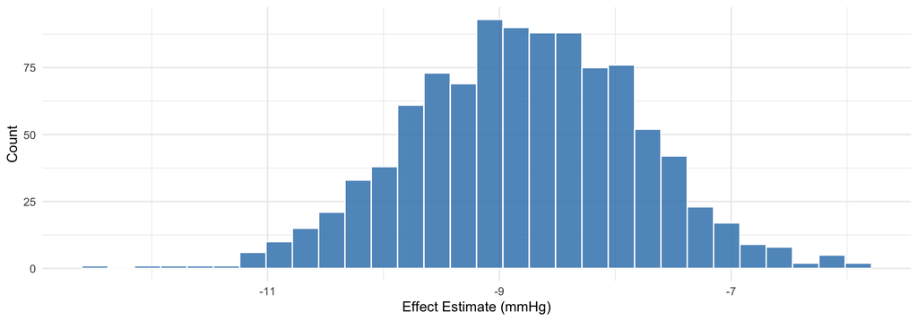

```r
ipw_results |>
  mutate(
    estimate = map_dbl(boot_fits,
      \(.fit) .fit |> filter(term == "exercise") |> pull(estimate))
  ) |>
  ggplot(aes(estimate)) +
  geom_histogram(fill = "#2c7bb6", color = "white", alpha = 0.8) +
  labs(x = "Effect Estimate (mmHg)", y = "Count") +
  theme_minimal()
```